# Modelos

#### Resultados

**Importante**

**Modelo m2a_tRandom**

Observaciones no incluidas en el modelo debido a valores faltantes en las covariables incluidas.

```
cambio_log_ferritina_t0                      HD                     Mes
                     19                       0                       0
         Aleatorización          Pauta (código)                      id
                      0                     190                       0
```

```
Linear mixed model fit by REML ['lmerMod']
Formula:
cambio_log_ferritina_t0 ~ HD + Mes + Aleatorización + `Pauta (código)` +
    Mes * Aleatorización + ((1 | id) + (0 + Mes | id))
   Data: data_m2
REML criterion at convergence: 283.2177
Random effects:
 Groups   Name        Std.Dev.
 id       (Intercept) 0.56828
 id.1     Mes         0.02891
 Residual             0.36982
Number of obs: 184, groups:  id, 52
Fixed Effects:
                (Intercept)                          HD1
                    0.10999                      0.31888
                        Mes      AleatorizaciónFerinject
                    0.03921                     -0.09157
          `Pauta (código)`3            `Pauta (código)`4
                   -0.05317                     -0.13748
          `Pauta (código)`2  Mes:AleatorizaciónFerinject
                   -0.35576                     -0.04502
```

```
 ============================================================
            DIAGNÓSTICO COMPLETO DEL MODELO
============================================================

1. PRUEBAS DE NORMALIDAD DE RESIDUOS:
   Shapiro-Wilk: W = 0.9745, p-valor = 0.0019
   Kolmogorov-Smirnov: D = 0.0602, p-valor = 0.5169
   ⚠ Los residuos NO son normales (p < 0.05) - pero modelos mixtos son robustos

2. HOMOCEDASTICIDAD:
   Test de heterocedasticidad: p = 0.2459
   ✓ Varianza constante (homocedasticidad) aceptable
```

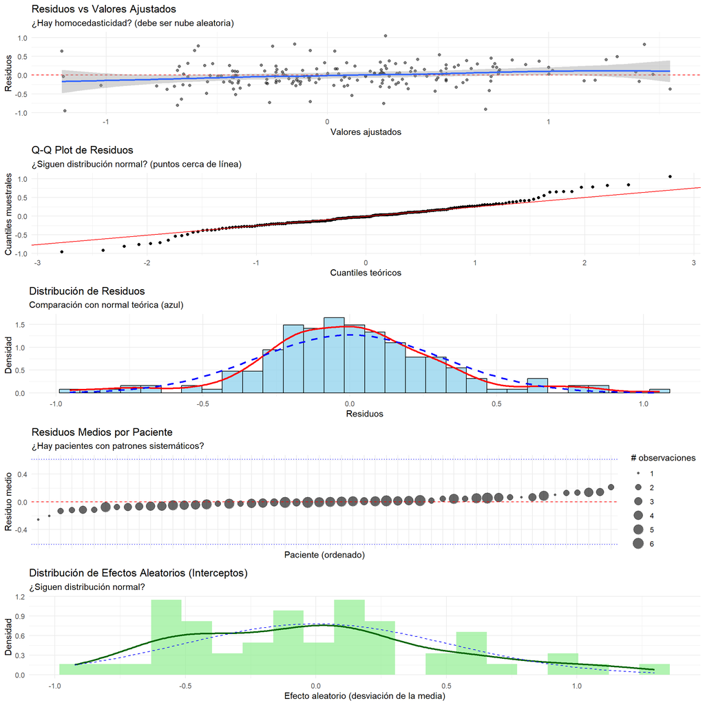

```
##                                   2.5 %      97.5 %
## .sig01                               NA          NA
## .sig02                               NA          NA
## .sigma                               NA          NA
## (Intercept)                 -0.50006210  0.72004302
## HD1                         -0.32432000  0.96207446
## Mes                         -0.01446534  0.09289467
## AleatorizaciónFerinject     -0.70773977  0.52459232
## `Pauta (código)`3           -0.60109315  0.49474668
## `Pauta (código)`4           -0.66315368  0.38819632
## `Pauta (código)`2           -0.68341882 -0.02810407
## Mes:AleatorizaciónFerinject -0.12127178  0.03122524
```

```
=== ANÁLISIS DEL ICC ===
ICC calculado: 0.702
Clasificación: Muy fuerte

COMPONENTES DE VARIANZA:
- Varianza entre sujetos: 0.3229 (70.2%)
- Varianza intra-sujeto: 0.1368 (29.8%)
- Varianza total: 0.4597

CONCLUSIONES CLÍNICAS Y ESTADÍSTICAS:
- ICC MUY ALTO: Mediciones fuertemente correlacionadas dentro de paciente
- Modelo mixto es CRUCIAL
- Variabilidad dominada por diferencias entre pacientes

RECOMENDACIONES:
• Tamaño medio del cluster: 3.5 obs/paciente
• Nº óptimo de mediciones/paciente: 0.8
• Mejor: MÁS pacientes, MENOS mediciones por paciente
```

```
$ICC
[1] 0.7024931

$Interpretacion_varianza
[1] "Dependencia intra-sujeto alta: modelo mixto imprescindible"
```

```
$emmeans
 Aleatorización emmean    SE   df lower.CL upper.CL
 Venofer        0.2637 0.281 90.0   -0.294    0.821
 Ferinject      0.0219 0.195 71.6   -0.367    0.410

Results are averaged over the levels of: HD, Pauta (código)
Degrees-of-freedom method: kenward-roger
Confidence level used: 0.95

$contrasts
 contrast            estimate    SE  df t.ratio p.value
 Venofer - Ferinject    0.242 0.313 123   0.772  0.4415

Results are averaged over the levels of: HD, Pauta (código)
Degrees-of-freedom method: kenward-roger
```

[figure not shown]

A medida que aumenta el tiempo, la diferencia en el efecto de cada rama de aleatorización es mayor aunque no llega a ser una diferencia significativa.

```
Mes = 0:
 contrast            estimate    SE  df t.ratio p.value
 Venofer - Ferinject   0.0916 0.319 134   0.287  0.7748

Mes = 1:
 contrast            estimate    SE  df t.ratio p.value
 Venofer - Ferinject   0.1366 0.312 127   0.438  0.6621

Mes = 2:
 contrast            estimate    SE  df t.ratio p.value
 Venofer - Ferinject   0.1816 0.309 123   0.588  0.5578

Mes = 3:
 contrast            estimate    SE  df t.ratio p.value
 Venofer - Ferinject   0.2266 0.311 123   0.728  0.4680

Mes = 4:
 contrast            estimate    SE  df t.ratio p.value
 Venofer - Ferinject   0.2717 0.318 123   0.853  0.3952

Mes = 5:
 contrast            estimate    SE  df t.ratio p.value
 Venofer - Ferinject   0.3167 0.330 121   0.959  0.3393

Mes = 6:
 contrast            estimate    SE  df t.ratio p.value
 Venofer - Ferinject   0.3617 0.346 114   1.046  0.2980

Results are averaged over the levels of: HD, Pauta (código)
Degrees-of-freedom method: kenward-roger
```

La falta de significación en las comparaciones punto a punto puede deberse a:  
- Bajo poder estadístico para detectar diferencias en puntos específicos  
- Alta variabilidad entre sujetos  
- **El efecto acumulativo necesita más tiempo para ser detectable**

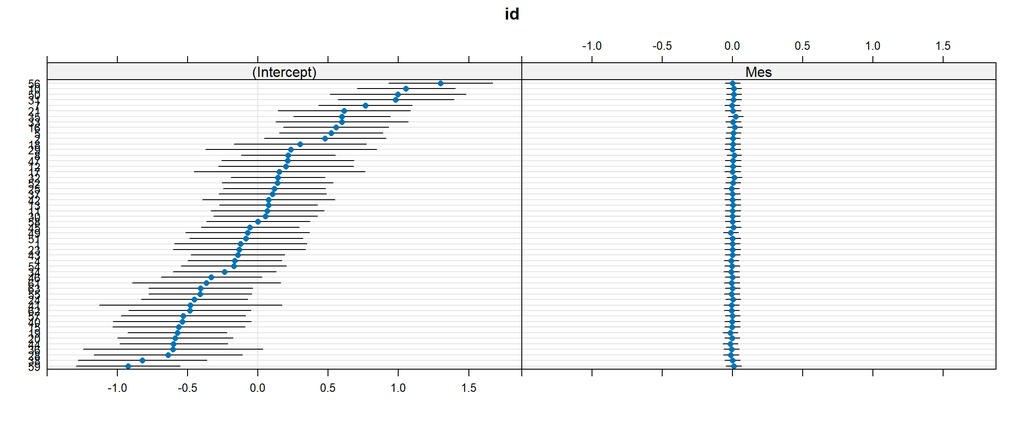

**Cada id tiene su intercepto propio (nivel inicial de cambio_log_ferritina_t0). Y también tiene su pendiente propia para Mes, que indica cómo cambia la variable con el tiempo para ese paciente.**

### Pendiente aleatoria (pauta | id) NO TERMINADO

¿La pauta debe ser factor aleatorio? ¿Hay variabilidad entre sujetos en la pauta?

**Nota**

Para predecir la log-ferritina es suficiente con el modelo de intersección aleatoria, no es necesario incluir pendiente aleatoria por pauta.

```
Data: data_m2
Models:
m1_0: log_Ferritina ~ HD + Mes + Aleatorización + `Pauta (código)` + log(ferritina_previa) + Mes * Aleatorización + (1 | id)
m1_1: log_Ferritina ~ HD + Mes + Aleatorización + `Pauta (código)` + log(ferritina_previa) + Mes * `Pauta (código)` + (1 + Mes | id)
     npar    AIC    BIC  logLik -2*log(L)  Chisq Df Pr(>Chisq)
m1_0   11 238.86 274.40 -108.43    216.86
m1_1   15 244.00 292.46 -107.00    214.00 2.8635  4     0.5809
```

```
 Groups   Name        Std.Dev.  Corr
 id       (Intercept) 0.1250834
          Mes         0.0093161 -1.000
 Residual             0.4188477
```

**Nota**

```
 Groups   Name        Std.Dev. Corr
 id       (Intercept) 0.360859
          Mes         0.078994 0.521
 Residual             0.238450
```

```
## Linear mixed model fit by maximum likelihood  ['lmerMod']
## Formula:
## cambio_log_ferritina_t0 ~ HD + Mes + Aleatorización + `Pauta (código)` +
##     cambio_log_ferritina_tmenos1 + Mes * `Pauta (código)` +
##     (1 + Mes | id)
##    Data: data_m2
##
##       AIC       BIC    logLik -2*log(L)  df.resid
##     184.2     232.2     -77.1     154.2       167
##
## Scaled residuals:
##      Min       1Q   Median       3Q      Max
## -2.24518 -0.53526  0.01708  0.47837  2.94968
##
## Random effects:
##  Groups   Name        Variance Std.Dev. Corr
##  id       (Intercept) 0.13022  0.36086
##           Mes         0.00624  0.07899  0.52
##  Residual             0.05686  0.23845
## Number of obs: 182, groups:  id, 52
##
## Fixed effects:
##                               Estimate Std. Error t value
## (Intercept)                  -0.044818   0.226187  -0.198
## HD1                           0.075921   0.247660   0.307
## Mes                           0.002399   0.026243   0.091
## AleatorizaciónFerinject       0.030433   0.220666   0.138
## `Pauta (código)`3            -0.041301   0.209248  -0.197
## `Pauta (código)`4             0.179546   0.522674   0.344
## `Pauta (código)`2            -1.966494   0.443242  -4.437
## cambio_log_ferritina_tmenos1  0.540388   0.043543  12.410
## Mes:`Pauta (código)`3         0.063534   0.036248   1.753
## Mes:`Pauta (código)`4        -0.227261   0.349672  -0.650
## Mes:`Pauta (código)`2         0.336527   0.092369   3.643
##
## Correlation of Fixed Effects:
##             (Intr) HD1    Mes    AltrzF `P()`3 `P()`4 `P()`2 cm___1 M:`P()`3
## HD1         -0.100
## Mes         -0.232  0.014
## AltrzcnFrnj -0.887 -0.090  0.122
## `Pat(cdg)`3 -0.903  0.109  0.247  0.778
## `Pat(cdg)`4 -0.336  0.042  0.064  0.289  0.341
## `Pat(cdg)`2 -0.027 -0.070  0.025  0.009  0.022  0.011
## cmb_lg_fr_1 -0.122 -0.020  0.042  0.080  0.075  0.054  0.139
## Ms:`P(cd)`3  0.198 -0.010 -0.723 -0.122 -0.280 -0.033 -0.012  0.011
## Ms:`P(cd)`4  0.231 -0.014  0.001 -0.220 -0.233 -0.940 -0.007 -0.043 -0.010
## Ms:`P(cd)`2  0.042  0.103 -0.139 -0.011 -0.038 -0.014 -0.952 -0.116  0.096
##             M:`P()`4
## HD1
## Mes
## AltrzcnFrnj
## `Pat(cdg)`3
## `Pat(cdg)`4
## `Pat(cdg)`2
## cmb_lg_fr_1
## Ms:`P(cd)`3
## Ms:`P(cd)`4
## Ms:`P(cd)`2  0.003
```

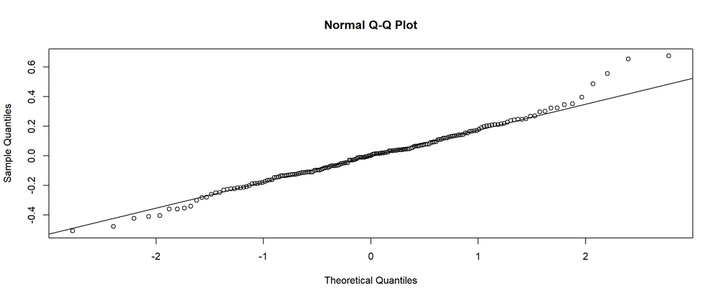

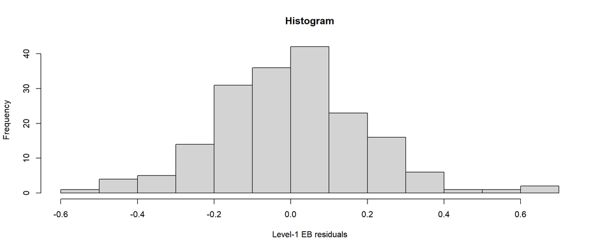

**Nota**

El modelo m1:

```
##                                   2.5 %     97.5 %
## .sig01                               NA         NA
## .sigma                               NA         NA
## (Intercept)                  1.56223240 3.08562088
## HD1                         -0.23280012 0.29895561
## Mes                         -0.06741331 0.03851590
## AleatorizaciónFerinject     -0.81530851 0.06240570
## `Pauta (código)`3           -0.68711977 0.08187821
## `Pauta (código)`4           -0.67920670 0.37922370
## `Pauta (código)`2           -0.42552444 0.19325423
## log(ferritina_previa)        0.59068853 0.79278705
## Mes:AleatorizaciónFerinject -0.09246684 0.05447954
```

**Nota**

El modelo m2_pautaRandom:

```
##                                    2.5 %      97.5 %
## .sig01                                NA          NA
## .sig02                                NA          NA
## .sig03                                NA          NA
## .sigma                                NA          NA
## (Intercept)                  -0.49670870  0.42608892
## HD1                          -0.41622113  0.61005373
## Mes                          -0.05070311  0.05724154
## AleatorizaciónFerinject      -0.43590637  0.46733137
## `Pauta (código)`3            -0.47788556  0.37458272
## `Pauta (código)`4            -0.91469666  1.21137190
## `Pauta (código)`2            -2.86323710 -1.08599779
## cambio_log_ferritina_tmenos1  0.44781064  0.62281932
## Mes:`Pauta (código)`3        -0.01165050  0.13761348
## Mes:`Pauta (código)`4        -0.92163260  0.50139122
## Mes:`Pauta (código)`2         0.15214222  0.52326602
```

## Ferritina (Valores óptimos)

```
# Overdispersion test

 dispersion ratio = 0.988
          p-value = 0.864
```

```
# Check for Multicollinearity

Low Correlation

                  Term  VIF    VIF 95% CI adj. VIF Tolerance Tolerance 95% CI
                    HD 1.16 [1.05,  1.47]     1.08      0.86     [0.68, 0.95]
                   Mes 2.09 [1.75,  2.60]     1.45      0.48     [0.39, 0.57]
 log(ferritina_previa) 1.13 [1.03,  1.46]     1.06      0.89     [0.68, 0.97]

Moderate Correlation

               Term  VIF    VIF 95% CI adj. VIF Tolerance Tolerance 95% CI
     Aleatorización 8.38 [6.59, 10.75]     2.89      0.12     [0.09, 0.15]
     Pauta (código) 5.73 [4.55,  7.32]     2.39      0.17     [0.14, 0.22]
 Mes:Aleatorización 6.31 [4.99,  8.06]     2.51      0.16     [0.12, 0.20]
```

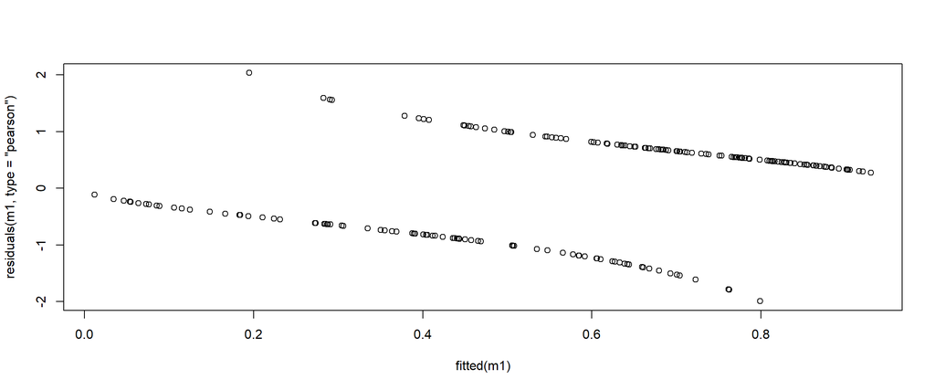

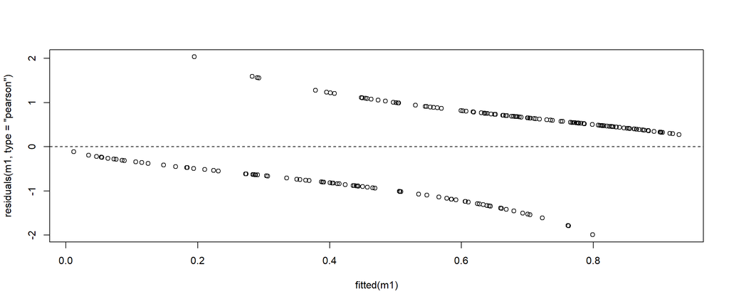